# Incorporating management action suitability in conservation plans - Carter - Journal of Applied Ecology - Wiley Online Library

[Journal of Applied Ecology](https://besjournals.onlinelibrary.wiley.com/journal/13652664)

[figure not shown]

RESEARCH ARTICLE

Open Access

# Incorporating management action suitability in conservation plans

[Zachary T. Carter](https://besjournals.onlinelibrary.wiley.com/action/doSearch?ContribAuthorRaw=Carter%2C+Zachary+T),

[Jeffrey O. Hanson](https://besjournals.onlinelibrary.wiley.com/action/doSearch?ContribAuthorRaw=Hanson%2C+Jeffrey+O),

[George L. W. Perry](https://besjournals.onlinelibrary.wiley.com/action/doSearch?ContribAuthorRaw=Perry%2C+George+L+W),

[James C. Russell](https://besjournals.onlinelibrary.wiley.com/action/doSearch?ContribAuthorRaw=Russell%2C+James+C),

First published: 04 September 2022

https://doi.org/10.1111/1365-2664.14258

**Handling Editor** Jacqueline Beggs

## Abstract

1. Conservation decision makers must negotiate social and technical complexities to achieve desired biodiversity outcomes. Quantitative models can inform decision making, by evaluating and predicting management outcomes, so that comparisons can be made between alternative courses of action. However, whether a proposed action is appropriate for implementation, regardless of its contribution to management outcomes, also requires consideration. Existing quantitative models have yet to fully incorporate the suitability of proposed management actions, which hinders their ability to inform decision making.
2. We used gradient boosted decision trees – a machine-learning technique – to determine the suitability of alternative management actions available to a biodiversity conservation programme. We demonstrate our approach using the Predator Free 2050 programme – a large and complex conservation initiative that seeks to eradicate selected invasive vertebrates from the entirety of New Zealand by 2050. We created a nationally contiguous network of management tools to suppress populations of invasive species across the entire country. We then used our suitability predictions to explore three scenarios for selecting invasive species management tools, based on maximising (a) implementation probability, (b) humaneness and (c) cost-savings.
3. Our models highlighted that an interplay of factors influence where management tools can potentially be implemented. Our management scenarios revealed what different contiguous management networks could look like for New Zealand over the next 10–15 years as an interim step to achieving Predator Free 2050. Each scenario differed in the tools selected for implementation in different places and in the overall economic costs associated with creating a contiguous management network. Some locations were identified as unsuitable for any existing management tools, indicating that future transformative technologies may be required to create a contiguous network.
4. *Synthesis and applications*. Conservation decision making must not only consider biodiversity outcomes but also whether selected management actions are appropriate in the first place. Here, we used machine-learning techniques to determine the suitability of competing managements actions that are proposed to meet biodiversity objectives. Our approach provides an objective, transparent and reproducible framework to determine the suitability of actions at sites across large spatial extents, under complex social and technical constraints.

## 1 INTRODUCTION

The conservation of biodiversity is fraught with complexity and uncertainty (Hemming et al., 2022). To deliver on conservation objectives, decision makers must navigate challenging social and technical contexts while contending with escalating threats (Maxwell et al., 2016). Quantitative models are frequently used to help guide the decision making process, providing insight into complex scenarios by way of attempting to remove unstructured subjective judgement (García-Díaz et al., 2019). As the scope and complexity of conservation objectives continues to increase, expert opinion alone will be insufficient to select between the range of actions proposed to meet objectives and so quantitative models will increasingly be relied upon to provide decision support (Farley et al., 2018).

A foundational component of decision making is determining the action(s) needed to meet objectives. Quantitative models are often used in this context to predict management outcomes so that alternative courses of action can be compared (Addison et al., 2013). These models assume proposed actions are equally likely to succeed once implemented or quantify the probabilistic uncertainty of specific outcomes occurring (Canessa et al., 2015; Regan et al., 2005). However, modern conservation occurs in a complex social-ecological landscape (Yletyinen et al., 2021) which affects whether a proposed action is more or less suitable for implementation in a given context. The probability of implementation is, therefore, not the same as the probability of success. Actions that appear suitable during the planning phases of a complex conservation objective may prove inappropriate during implementation, ultimately resulting in delayed or compromised outcomes (Canessa et al., 2020). Thus, quantitative models for informing conservation decisions would benefit immensely from information on the probability that actions can be successfully implemented in a given landscape.

Machine-learning is a suite of statistical techniques that is used to identify structure in complex data and to generate predictive models (Olden et al., 2008). These techniques are particularly useful for identifying patterns and drivers without assuming a priori structural relationships. Machine-learning has been widely used in ecology, including for species distribution modelling (Elith & Leathwick, 2009), image recognition (Fairbrass et al., 2019) and other instances where predictive performance is paramount (Van Doren & Horton, 2018). This utility appears well suited to disentangling the complex social and technical relationships associated with implementing actions in order to determine their suitability in a given landscape.

Here, we use a novel application of machine-learning techniques to predict the suitability of management actions proposed for a biodiversity conservation programme across a large spatial extent. We frame our study using New Zealand's Predator Free (PF 2050) initiative, which seeks to eradicate biologically and economically harmful invasive vertebrate mammals from New Zealand by 2050 (i.e. rats *Rattus rattus*, *R. norvegicus*, *R. exulans*; stoats *Mustela erminea*, *M. furo*, *M. nivalis;* and the common brushtail possum *Trichosurus vulpecula*; Russell, Innes, et al., 2015). To assist in achieving the foundational goal of the national coverage of actions, we use machine-learning techniques to (a) identify factors that played a past role in successfully implementing different management actions at sites and (b) predict where different management actions could be suitably implemented in the future at sites. We then demonstrate the applicability of our approach using scenario analysis to (c) explore how the implementation of these actions would vary throughout the country by individually maximising cost-savings, humaneness and implementation probability. Our methodological approach provides decision makers with an objective, transparent and reproducible framework to determine the suitability of competing actions across large spatial extents and under complex and uncertain social and technical constraints.

## 2 MATERIALS AND METHODS

### 2.1 Study system

Invasive species management actions are enacted by implementing tools to suppress or eradicate a population in an area or set of areas (hereafter ‘management tools’ or ‘tools’). PF 2050 is a government-sponsored initiative that has been well-supported both socially and financially since its adoption in 2016. Indeed, the New Zealand government has championed the activities of 5,000 different community groups and iwi (i.e. Māori tribes) with an annual contribution of approximately $75 million NZD (totalling over $350 million NZD from 2016–2020) (Department of Conservation, 2020, 2021). Currently, PF 2050 is a patchwork of management tools implemented both top-down nationally by government agencies and bottom-up by individual community groups. This approach has resulted in incomplete coverage, where some locations have invasive species management and others do not. Since eradication cannot be achieved nationally using currently available tools (Murphy et al., 2019; Peltzer et al., 2019), our analysis focuses on achieving complete national coverage for ongoing invasive species suppression by implementing existing tools, anticipating the availability of transformative eradication technologies in the future.

We conducted our analysis across the main New Zealand islands (hereafter ‘the mainland’; Figure 1a), a region spanning the North Island *Te Ika-a-Māui* (106,097 km<sup>2</sup>), South Island *Te Waipounamu* (165,693 km<sup>2</sup>), Great Barrier Island *Aotea* (242 km<sup>2</sup>) and Stewart Island *Rakiura* (2,055 km<sup>2</sup>). We used a 1 × 1 km spatial grid (267,704 grid cells) to define the spatial scale of our analysis. We used this resolution because it is sufficient to capture the existing and known locations of management tools and to investigate their relationships with selected predictor variables. Although New Zealand has many offshore/outlying islands invaded by terrestrial mammals, we excluded these areas from analysis because they are currently managed independently of the mainland and, for most, eradication is currently achievable (Carter et al., 2021). Additionally, we excluded areas uninhabited by terrestrial mammals, including lakes and high-elevation areas (≥1,500 m, which represents an approximate average of the range that target mammals can persist in alpine environments; O'Donnell et al., 2017). All data processing used the R statistical environment (version 4.0.2; R Core Team, 2017) and ArcGIS 10.7.1 (ESRI, 2011).

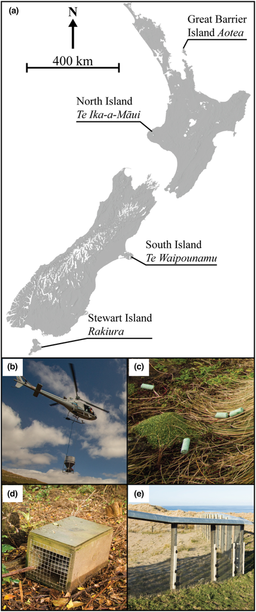

**FIGURE 1**

Depiction of (a) the study area (mainland New Zealand; shaded in grey, excluding lakes and high-elevation areas) and management tools including (b) aerially broadcast poisons, (c) hand-broadcast poison baits, (d) a kill-trap housing unit and (e) a predator exclusion fence. Image credits: J. C. Russell (b–d), J. Innes (e).

Four tools are primarily used to manage invasive mammalian predators in New Zealand – aerially broadcast poisons, ground-based poisons, kill-traps and exclusion fences (Figure 1b–e). Briefly, vertebrate pesticides (as palatable cereal baits) are sown aerially from helicopters with underslung bucket spreaders, or on the ground by hand, in bait-bags or in bait-stations; kill-traps attract individuals and use a striking mechanism to kill them; exclusion fences are designed to prevent the passage of animals into a location. Although these tools are sometimes perceived as unpalatable or uncompassionate, lethal control of invasive mammals has been crucial to preventing extinctions of island biota around the world and is – for the most part – accepted in New Zealand (Russell, Innes, et al., 2015; Russell, Jones, et al., 2015). We investigated factors correlating to locations where aerially broadcast poisons, ground-based poisons, kill-traps and exclusion fences have been applied in the past, to predict where they can be suitably implemented in the future.

### 2.2 Management tool data

We collated records of locations where management tools (Figure S1) have been implemented over the past 26 years (1995–2021) from data provided by the Predator Free New Zealand Trust (PFNZ Trust; R. Bell pers. comm. 2020), TrapNZ (P. Handford and D. Bar-Even pers. comms. 2020) Manaaki Whenua – Landcare Research (Landcare Research; J. Innes and N. Fitzgerald pers. comms. 2020) and the Department of Conservation (DOC; P. McMurtrie and P. Eschenmoser pers. comms. 2021). Data from the PFNZ Trust and DOC delineated the boundaries of implemented management activities (e.g. the enclosed area of a trapping grid or the treated area of an aerially broadcast poison operation), and TrapNZ data detailed the location of management tools as geographic coordinates (i.e. each trap received its own unique coordinate location). Exclusion fences ≥0.25 km<sup>2</sup> were identified using coordinate centroids provided by Landcare Research (Innes et al., 2019); exclusion fences <0.25 km<sup>2</sup> were identified using Burns et al. (2012) or from the personal contacts of Landcare Research experts. Boundaries of exclusion fences were obtained by manually digitising aerial images or were provided by eco-sanctuary managers and owners.

We overlaid the management tool data on the 1 km spatial grid to identify grid cells where each management tool has previously been implemented. We then generated a map (hereafter, ‘bias map’; Elith et al., 2008) to reflect past implementation bias in our presence–absence records and to account for sampling bias in our presence-only records, during model fitting (Figure S2). These maps ensured our models were informed but were not solely driven by historical management practices and records (see Appendix S1 for complete details on the pre-processing of occurrence records and on bias map generation).

### 2.3 Predictors of past management tool implementation

The successful implementation of invasive species management tools depends on a range of biogeographical and social factors (Carter et al., 2021; Courchamp et al., 2003; Holmes et al., 2015; Oppel et al., 2011). Biophysical factors, such as geographical isolation and geomorphic features, logistically constrain which tools can be implemented. For example, isolated areas that are far from people preclude the use of tools with regular servicing requirements (e.g. kill-traps or ground-based poisons; Brown et al., 2015). Additionally, areas located near water bodies are better suited for tools that leverage such natural dispersal barriers to reduce implementation costs (e.g. exclusion fences; Burns et al., 2012). Social factors, such as human population density and complexity of the social context (e.g. the number of different landowners), influence the viability of implementing certain management tools based on real and perceived impacts (Niemiec et al., 2016; Oppel et al., 2011).

We obtained multiple datasets to source variables for our models. These datasets were provided by Land Institute New Zealand (e.g. Land Information New Zealand, 2018), Landcare Research [e.g. the Landcover Database (LCDB); Manaaki Whenua – Landcare Research, 2020], the Land Use and Carbon Analysis System (LUCAS; Newsome et al., 2018), DOC (Department of Conservation, 2017; J. Kemp and N. Gorman, pers. comms.), the Māori Land Court (Maori Land Court, 2017) and the International Union for Conservation of Nature (IUCN; BirdLife International, 2017).

We generated 23 biogeographic and land-tenure based predictor variables (Table S1; Figure S3) to model the suitability of implementing tools across the mainland (see Appendix S1 and Table S2 for complete details). To assist interpretation, we classified our biogeographic predictors as geomorphic, landscape related or land cover related. Specifically, these variables were (geomorphic:) mean slope, mean elevation, distance to water, cost distance; (landscape:) mean of core area index (mean CAI), related circumscribing circle (RCC), landscape shape index; (land cover:) cropland, grassland, shrub/scrub-land and forest. We classified our land-tenure predictors as land cover related, tenure related or non-target species. These variables included (land cover:) urban, building density; (tenure:) public conservation land, private land, Māori (iwi) land and (non-target species:) the number of sensitive endemic species (hereafter ‘sensitive endemics’). We accounted for spatial autocorrelation in mean CAI, RCC, tenure-related variables and sensitive endemics by calculating focal mean statistics at a 20 km diameter (Figure S4). This choice was validated by measuring the effective spatial autocorrelation range with the Block CV R package (v2.2.1; Valavi et al., 2019). Finally, to account for categorical differences between the two main islands of New Zealand, we included an additional variable indicating whether a grid cell was in the North or South Island.

### 2.4 Model fitting and evaluation

We used machine-learning to combine multiple relatively simple models into a single more-complex model with increased predictive performance (Polikar, 2012). There are multiple ways to combine models (e.g. bagging, boosting and stacking; Breiman, 1996; Schapire, 1990); however, we selected boosting because it has demonstrated strong predictive performance in similar studies, is robust against multicollinearity, and can reliably identify important predictors (Friedman, 2001). We specifically used a variant of the gradient boosting algorithm due to recent advances in scalability (Chen & Guestrin, 2016), which decreases processing time for large and complex datasets relative to other boosting algorithms (*c.f*. adaptive boosting, ‘adaboost’; Freund & Schapire, 1997).

We fitted gradient boosted decision trees separately for each management tool (via the XGBoost r package; v1.2.0.1; Chen et al., 2020). For each tool, we denoted presences using grid cells in which tools had been implemented and denoted pseudo-absences by randomly sampling 5,000 grid cells from grid cells without previously recorded tool use. To account for biases in the locations where management tools have been reported to be implemented, pseudo-absence locations were randomly sampled using weights based on the bias map generated for each management tool. All models were trained using the previously described 24 variables and a logit link function to accommodate the presence/pseudo-absence data. To increase model performance, we also conducted a model calibration analysis that involved fitting the models with different combinations of tuning parameters and evaluated them using fivefold cross validation (see Appendix S2 for tuning parameters). After fitting the models, we used the area under the curve (AUC) statistic to identify the best model for each tool.

We used the best model for each management tool to predict the spatial distribution of implementation suitability across the mainland. Specifically, for each management tool we generated a continuous map that described the suitability of implementing a tool in each grid, based on our predictor variables (Figure S5). We then applied thresholds to the continuous maps – identified by maximising the sum of the sensitivity and specificity statistics – to create binary maps that indicate whether each tool was suitable for implementation (Figure S6, wherein 0 = not suitable, 1 = suitable; Liu et al., 2005). These binary suitability maps had AUC scores of 0.87 ± 0.01 *SD*, 0.88 ± 0.00 *SD*, 0.89 ± 0.01 *SD* and 0.93 ± 0.05 *SD* for aerially broadcast poisons, ground-based poisons, kill-traps and exclusion fences, respectively (Table S2). Thus, given the aims of our study, we are confident each model had adequate predictive performance (i.e. all models had >0.75 AUC; Pearce & Ferrier, 2000).

For each model we then identified the most important predictors by measuring the ability of each variable to cluster similar residuals (i.e. the variables' ‘gain’) and visualised their influence using centred individual conditional expectation (c-ICE) plots (Goldstein et al., 2015). Additionally, we investigated the uncertainty in our predictions by mapping the environmental similarity surface for each model (Elith et al., 2010).

### 2.5 Management scenarios

We conducted a scenario analysis (reviewed in Peterson et al., 2003) of enacting different combinations of invasive species management actions throughout the landscape. We considered three scenarios based on important factors influencing management tool selection (Brown et al., 2015). Each scenario allocated a tool to each grid cell based on certain criteria. In some instances, all four tools were excluded from a grid cell due to them being unsuitable (identified via our binary suitability maps; Figure S6), in which case we allocated a fifth ‘future’ tool to create a contiguous management network. A lack of suitable tools means future transformative technologies may be required to achieve PF 2050 (Murphy et al., 2019); however, such locations identified in this study may also be novel environments yet to undergo invasive species management (but are suitable for current management tools). We use the term ‘future’ for both conditions.

#### 2.5.1 Suitability scenario

We generated a scenario that aimed to maximise the probability of successfully implementing management tools in the landscape. This scenario was created by allocating the most suitable tool (based on our continuous suitability maps, see Figure S5) to each grid cell and represents a possible future where creating a contiguous national management network is paramount and other factors, such as cost, are secondary. Indeed, New Zealand's government, supporting bodies and community groups are committed to achieving PF 2050 (Department of Conservation, 2020), and this scenario reflects their desire to see this initiative be successful.

#### 2.5.2 Humaneness scenario

We generated a scenario that aimed to maximise the humaneness of management tools selected for implementation (Table 1). Since conducting invasive species management requires tools that are socially acceptable (Oppel et al., 2011), this scenario reflects preference for more humane tools. We created this scenario by allocating the single-most humane tool, from among those that were suitable, to each grid cell. We quantified humaneness using the Sharp and Saunders (2011) two-part assessment framework, which integrates (a) welfare impacts and (b) intensity/duration of suffering, using a single alphanumerical score (Table S3). We converted each tool's score to an ordered factor (1–5, from most to least humane; Figure S7) so they could be included in our management scenarios.

TABLE 1. Summary of humaneness and cost data used to inform the scenario analyses conducted in this study

| Management tool | Humaneness Humaneness score<sup>a</sup> | Humaneness Citation<sup>b</sup> | Cost Cost range ($ ha<sup>−1</sup>) | Cost Average per-unit cost ($ ha<sup>−1</sup> year<sup>−1</sup>)<sup>c</sup> | Cost Cost ratio<sup>c</sup><sup>,</sup><sup>d</sup> | Cost Citation<sup>b</sup> |
| --- | --- | --- | --- | --- | --- | --- |
| Aerially broadcast poisons | 4 | 1, 2 | 8–24 | 5 | 1 | 1–3 |
| Ground-based poisons | 5 | 3–8 | 4–80 | 14 | 3 | 1, 3, 4 |
| Kill-traps | 2 | 9, 10 | 7–200 | 15 | 3 | 5, 6 |
| Exclusion fences | 1 | 11, 12 | 7–12 k | 328 | 60 | 7–9 |

- <sup>a</sup> Derived from Sharp and Saunders (2011), where 1 is most humane and 5 is most inhumane.
- <sup>b</sup> See Appendix S3.
- <sup>c</sup> Rounded to the nearest integer value.
- <sup>d</sup> Relative to aerially broadcast poisons.

#### 2.5.3 Cost-savings scenario

We generated a scenario that aimed to maximise cost-savings by minimising the expenditure associated with implementing and maintaining management tools (Table 1). Given that cost is a perennially limiting factor in conservation (Wilson & Law, 2016) and that PF 2050 is a major long-term undertaking, this scenario reflects strategies to conduct sustainable, prolonged invasive species management. We created this scenario by allocating the single cheapest tool, from among those that were suitable, to each grid cell. Our cost-savings scenario considered the cost of implementing and maintaining management tools for the entirety of the PF 2050 initiative (i.e. 29 years: 2021–2050). Cost values were an average of the plausible cost range identified using case studies (from the primary literature and government documents) that summed the per-unit operational cost of enacting an entire management operation (i.e. inclusive of labour and planning, among other costs). Each per-unit cost estimate was converted to a per-unit annual estimate by considering the longevity of each management tool (e.g. aerially broadcast poisons must be sown once every 3 years to maintain target invasive species at low densities) so that fair comparisons could be made. Since it was not a primary aim of the study to provide detailed cost estimates for the PF 2050 programme, we converted each per-unit annual estimate into a ratio relative to the cheapest management tool. This conversion enabled us to compare the magnitude of costs across scenarios without pricing an invasive species management programme nationally. Although this scenario might be used as a starting position to generate cost estimates, it by no means considers all costs and benefits associated with the programme.

## 3 RESULTS

Each model drew upon a suite of variables to predict the suitability of each management tool (Figure 2). In other words, there was not a single variable that alone effectively predicted whether each tool could be successfully implemented at a given locality. Moreover, variables analysed at the 20 km diameter scale were generally more important than those same variables analysed at 1 km (Figure 2). Landscape metrics, including mean CAI and RCC, were important predictors (mean gain = 0.130 ± 0.03 *SD* and 0.120 ± 0.02 *SD* for mean CAI and RCC, respectively, across all management tools at the 20 km diameter scale), indicating that landscape scale (i.e. expansiveness), contiguity and shape influence where management tools can be implemented. Geomorphic variables describing cost distance (i.e. the per-unit time required to walk 1 km), mean elevation and distance to water (i.e. major lacustrine waterbody) also played an important role in determining where management tools can be implemented (mean gain = 0.109 ± 0.02 *SD*, 0.116 ± 0.03 *SD* and 0.095 ± 0.0 *SD* for cost distance, mean elevation and distance to water, respectively, across all management tools). Notably, tenure (i.e. the number of private or Māori [iwi] landowners) was not influential in any model, and there were no marked differences between the North and South Island (mean gain = 0.007 ± 0.01 *SD* across both factor levels).

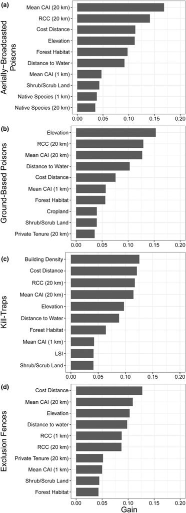

**FIGURE 2**

Relative importance of the top 10 predictor variables in determining where management tools can be implemented in New Zealand. Data show the gain for each variable. See Table S4 for a complete list of gain values for all predictor variables in relation to each management tool, and Figures S10–S13 to see how each predictor variable influenced the mean of predicted implementation probability (i.e. c-ICE plots).

Many of the areas identified by the models as suitable for tool implementation in the future align with spatial patterns of past tool implementation (Figure S8). For example, coverage gaps for ground-based poisons were predicted to be filled-in, such as between the regions of Gisborne and Hawke's Bay and between Otago and Southland (see Figure 3 for a map of regions and features). Similarly, exclusion fences were predicted to be suitable in naturally defendable locations such as fiords/sounds (i.e. Marlborough Sounds), peninsulas (e.g. Banks Peninsula, Farewell Spit), mountainous regions and along coastlines, where they have been implemented in the past (Figure S9). We note exclusion fences were predicted to have the most limited implementation overall, which likely reflects the novelty of this technology such that few exclusion fences have been established to date.

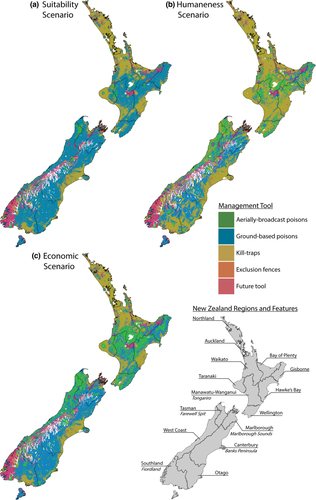

**FIGURE 3**

Management scenarios to create a contiguous network of management tools throughout New Zealand that individually maximise (a) implementation probability, (b) humaneness and (c) cost-effectiveness. Regional council boundaries and features mentioned in-text are labelled (bottom-right).

TABLE 2. Summary of costs and extent of invasive species management scenarios for implementing contiguous management tools across New Zealand

[output not shown]

- <sup>a</sup> Relative to the cost-savings scenario. Ratios do not consider the cost of implementing future tools.
- <sup>b</sup> Describes historical management tool distribution (1995–2021). Note that historical land-area does not sum to the total land-area considered in this study because management tools have not been implemented continuously throughout New Zealand and some management tools have been implemented simultaneously at a particular location.

Allocating management tools based on different criteria will influence the overall financial cost of managing invasive species across the mainland. The humaneness and suitability scenarios were approximately 10% and 20% more expensive, respectively, than the cost-savings scenario (Table 2). This difference in cost is primarily driven by differences in the use of aerially broadcast poisons, which are employed most frequently in the cost-savings scenario. This finding highlights the importance of using aerially broadcast poisons to cost-effectively manage invasive mammals across large tracts of New Zealand (Elliott & Kemp, 2016).

Our models identified that existing tools may be unsuitable for some areas of the mainland. Overall, 89% of the eligible country (238,518 km<sup>2</sup>) was predicted as being suitable for existing tools and all four islands were predicted to require a future tool to create a contiguous management network. Areas requiring a future tool tended to be geographically clustered. For example, the South Island contained the largest area requiring a future tool (comprising 21,802 km<sup>2</sup> or 74.7% of all predicted future tool area), the majority occurring in Fiordland and mountainous regions of the West Coast (Figure 3).

## 4 DISCUSSION

We aimed to determine the suitability of competing actions for achieving national coverage in invasive mammal management for New Zealand's PF 2050 initiative. By using machine-learning techniques to generate suitability predictions, and scenario analyses to explore tool-use configurations to meet different objectives, we investigated what a contiguous national management network for suppression could look like prior to implementing eradication. Our models suggest that different parts of the landscape are more suitable for certain management tools than others, which will translate to different courses of action depending on the implemented scenario. Our study represents the first strategic national assessment of PF 2050 tool deployment and highlights how our novel modelling approach can inform complex, landscape-scale conservation objectives. We envision our research being informative to policy-makers who can incorporate it alongside other considerations to address national and international challenges related to global change, such as biosecurity (Faulkner et al., 2020), climate change (Kappes et al., 2021) and human well-being (de Wit et al., 2020).

We have demonstrated the importance of broad-scale factors when considering how suitable an area is for implementing management tools. These results highlight the complex interplay of factors managers must consider when determining where a management tool can and should be implemented. For example, mean CAI 20 km (contiguousness and expansiveness of landscape features within 20 km centred on a given grid cell; Table S1) was predicted to be the single-most important factor in determining where aerially broadcast poisons can be implemented (Figure 2a). This variable exhibited a highly non-linear relationship with implementation probability (see Figure S10), suggesting that the effect of landscape contiguousness and expansiveness on the suitability of aerially broadcast poisons is context-dependent and that trends may not be scalable nationally. Indeed, the complexity of this relationship highlights the importance of engaging with conservation practitioners and local experts when designing conservation plans at increasing spatial extents (Crowley et al., 2017). This expertise will be essential for integrating existing local management actions into larger cohesive units as programmes continue to expand, particularly across regional jurisdictions, throughout New Zealand (Peltzer et al., 2019).

Our models suggest that land-tenure has relatively little importance in determining where management tools can be successfully implemented (Figure 2). This result contrasts with previous studies that have investigated the causal mechanisms underlying successful invasive species management in inhabited areas (e.g. Niemiec et al., 2016). One explanation for this discrepancy is that our land-tenure metrics were too coarse to fully capture social complexity (Beever et al., 2019). Although the metrics used in this study are likely to be sufficient proxies for human habitation and social complexity on smaller, sparsely populated islands (e.g. Carter et al., 2021), they may not be sufficient for densely populated mainland areas. Another explanation is that many of our derived biophysical variables – including cost distance, distance to water, mean CAI and RCC (Table S1) – already implicitly incorporate aspects of land-tenure. For example, cost distance measures the per-unit time (in minutes/km) required to traverse the landscape from the nearest vehicle-accessible trail to the centre of a focal cell. Although we used gradient boosted decision trees because they are robust to multicollinearity, cost distance was significantly negatively correlated with private land at the 20 km scale, which may have caused our modelling approach to underestimate variable importance scores for private land (i.e. residual clustering occurred more for cost distance than for private land; Chen & Guestrin, 2016). Disentangling the complex socio-ecological factors associated with enabling invasive species management action throughout New Zealand will require investigation of social factors specific to individual regions for which data are not yet readily available across large geographic scales.

Our management scenarios reveal multiple considerations important to PF 2050. First, kill-traps and aerially broadcast poisons appear to be suitable for implementation across large swaths of land but are currently not used to their full potential. For example, when compared to historical tool use (Table 2), the area allocated to kill-traps and aerially broadcast poisons can be increased up to 5.8- and 1.8-times their previous levels, respectively. Second, given the relatively small area allocated to exclusion fences under all three scenarios, it would seem likely that exclusion fences will have limited further applicability (Figure 3; Table 2). Although exclusion fences are essential to safeguarding vulnerable species from predation (Burns et al., 2012) – serving a vital role in nationwide invasive species management – their relatively high cost, and small number of suitable locations may preclude their broad usage across the mainland (Table 1). Third, our models indicate that approximately 10.9% of New Zealand's land-area, especially higher elevations, is unsuitable for any of the existing management tools, necessitating implementation of a future tool(s), or novel application of an existing tool(s), to create a contiguous management network (Figure 3). Clusters of areas were predicted to be unsuitable for existing management tools. For example, multiple areas with inaccessible terrain (Figure S3c), such as Fiordland and Tongariro (Figure 3), were predicted to require future tools. This outcome may coincide with the difficulty in implementing current tools in these areas rather than the appropriateness of tools per se. Indeed transformative technologies are being developed to overcome such accessibility issues (Murphy et al., 2019); however, practitioners must disentangle whether an area truly requires transformative technologies or if it has only yet to undergo invasive species management because it is remote or has not previously been a conservation priority.

Our approach provides a framework to assist in formulating management alternatives for conservation planners (and hence contributes to existing planning paradigms, such as dynamic adaptive policy pathways; Haasnoot et al., 2013). Alternate implementation pathways are a cornerstone of structured decision making but developing them can be challenging – especially when cognitive biases, differing value judgements, and/or competing interests are present (Hemming et al., 2022). We suggest that our framework can assist in overcoming such challenges by querying commonly held – and often fallacious – beliefs that an existing or current action remains the only option suitable to meet an objective (i.e. the *status quo* bias; Gregory et al., 2012). Moreover, our framework can assist decision makers in provisioning pragmatic solutions; rather than identifying ideal actions that may not be practical, our approach identifies satisfactory solutions with the highest probability of being implemented. Future studies can extend our approach by considering the efficacy of selected alternatives in meeting objectives (e.g. via density-impact functions; Green & Grosholz, 2021) to inform subsequent steps of the structured decision making process (see Appendix S4 for further considerations and study limitations).

## AUTHOR CONTRIBUTIONS

Zachary T. Carter and James C. Russell conceived the study; Zachary T. Carter and Jeffrey O. Hanson collected and analysed the data; Zachary T. Carter led in writing the manuscript; all authors contributed substantially to revising the text and gave final approval for publication.

## ACKNOWLEDGEMENTS

We are grateful to the many individuals and groups who contributed data to this project. Specifically, we would like to thank Rebecca Bell of the Predator Free New Zealand Trust; Peter Handford and Daniel Bar-Even of GroundTruth; John Innes and Neil Fitzgerald of Manaaki Whenua – Landcare Research; Pete McMurtrie, Patrik Eschenmoser, Josh Kemp and Nicholas Gorman of the Department of Conservation; Bruce Burns at the University of Auckland; as well as numerous eco-sanctuary managers and owners for giving us permissions to include their eco-sanctuaries in our study. Z.T.C. was supported by a New Zealand International Doctoral Research scholarship, a University of Auckland Faculty of Science 2021 PhD Output Award, and Predator Free 2050 Ltd; J.O.H. was supported by Environmental and Climate Change Canada (ECCC) and Nature Conservancy of Canada (NCC); J.C.R. was supported by the Royal Society of New Zealand Rutherford Discovery Fellowship (Grant No. RDF-UOA1404), and New Zealand's Biological Heritage National Science Challenge. Thanks to the reviewers and editor for feedback on earlier drafts of the manuscript and to Wareko Te Angina for the abstract translation. Open access publishing facilitated by The University of Auckland, as part of the Wiley - The University of Auckland agreement via the Council of Australian University Librarians.

## CONFLICT OF INTEREST

Z.T.C. was funded by Predator Free 2050 Ltd; J.C.R. is advisor to Zero Invasive Predators, the Predator Free New Zealand Trust and Predator Free 2050 Ltd.

[figure not shown]

[figure not shown]